# Repository inventory

Published

14 July 2026

A live manifest of what this repository tracks: the data files under `data/` and the exported figures under `figures/`, both listed straight from disk so the page always matches what is committed. Filenames carry processing date-stamps that change on reprocessing, so this page is generated, not hand-maintained. Re-run it after regenerating data or figures to refresh it.

The raw `00-*` inputs are tracked for provenance and never written to; the derived stages (`01-` onward) are regenerated by the pipeline notebooks and tracked as a committed snapshot. See Data for what each stage means and how it maps onto the processing versions.

## Imports and helpers

```python
import base64
import re
from datetime import datetime
from pathlib import Path

import pandas as pd
from IPython.display import display, Markdown, HTML

NB_START = datetime.now()  # notebook start time (reported in the last cell)

# Tracked datasets live under data/ (raw 00-* inputs and derived stages);
# exported figures live under figures/.
DATA = Path("../data")
FIGDIR = Path("../figures")


def human_size(n):
    """Human-readable byte size."""
    n = float(n)
    for unit in ["B", "KB", "MB", "GB", "TB"]:
        if n < 1024 or unit == "TB":
            return f"{n:.0f} {unit}" if unit == "B" else f"{n:.1f} {unit}"
        n /= 1024


def scenario_of(name):
    """Leading scenario code in a filename (e.g. 'QCL-1'), or '' if none."""
    m = re.match(r"([A-Z]+-\d+)", name)
    return m.group(1) if m else ""


def folder_table(folder, pattern="*"):
    """One row per file in `folder` matching `pattern`: name, scenario, size."""
    rows = [
        {"file": f.name, "scenario": scenario_of(f.name),
         "size": human_size(f.stat().st_size)}
        for f in sorted(Path(folder).glob(pattern)) if f.is_file()
    ]
    return pd.DataFrame(rows)
```

## EddyPro flux output (`00-eddypro_fluxes_level-1/`)

One FLUXNET-format CSV per scenario, all five (`*-1` to `*-5`). For the PWB scenario (`*-5`) the lag was removed from the raw data before the EddyPro run, so that run applied no lag compensation. These are the raw inputs to notebook 01.

```python
folder_table(DATA / "00-eddypro_fluxes_level-1", "*_adv.csv")
```

|  | file | scenario | size |
| --- | --- | --- | --- |
| 0 | LGR-1_eddypro_LGR-1_FR-20260619-164852_fluxnet... | LGR-1 | 27.9 MB |
| 1 | LGR-2_eddypro_LGR-2_FR-20260615-140834_fluxnet... | LGR-2 | 27.8 MB |
| 2 | LGR-3_eddypro_LGR-3_FR-20260615-140917_fluxnet... | LGR-3 | 27.8 MB |
| 3 | LGR-4_eddypro_LGR-4_FR-20260623-133726_fluxnet... | LGR-4 | 27.8 MB |
| 4 | LGR-5_eddypro_LGR-5_FR-20260622-174418_fluxnet... | LGR-5 | 27.8 MB |
| 5 | QCL-1_eddypro_QCL-1_FR-20260619-164952_fluxnet... | QCL-1 | 34.1 MB |
| 6 | QCL-2_eddypro_QCL-2_FR-20260615-140229_fluxnet... | QCL-2 | 33.9 MB |
| 7 | QCL-3_eddypro_QCL-3_FR-20260615-140311_fluxnet... | QCL-3 | 34.0 MB |
| 8 | QCL-4_eddypro_QCL-4_FR-20260623-134019_fluxnet... | QCL-4 | 34.0 MB |
| 9 | QCL-5_eddypro_QCL-5_FR-20260622-174805_fluxnet... | QCL-5 | 33.9 MB |

## EddyPro settings (`00-eddypro_settings/`)

The EddyPro project (`.eddypro`) and metadata (`.metadata`) files that produced each flux output. Every run shares the same site, period, raw signal, and all other EddyPro options; the **only** thing that differs is how the N₂O / CH₄ time lag is handled. The table reads that difference straight from the files: the time lag method (`tlag_meth` in the `.eddypro`) and the per-gas search window (nominal lag and min to max, from the active gas column in the `.metadata`). Keep these in sync with the processing versions.

```python
# Read the actual time-lag settings from each scenario's EddyPro files so the
# differences between runs are auditable, not hardcoded. The only setting that
# varies across runs is the time-lag treatment: the method (`tlag_meth` in the
# .eddypro) and the per-gas search window (in the .metadata).

# EddyPro time-lag method codes.
TLAG_METH = {
    "0": "None (lag removed from raw data, PWB)",
    "1": "Constant lag",
    "2": "Covariance maximization, default fallback",
    "3": "Covariance maximization, no default",
    "4": "Automatic optimization",
}


def read_tlag_meth(epro_path):
    # The tlag_meth code and label from an .eddypro file.
    m = re.search(r"^tlag_meth=(\d+)", epro_path.read_text(), re.M)
    code = m.group(1) if m else ""
    return code, TLAG_METH.get(code, "(unknown)")


def read_gas_window(meta_path, gas):
    # Nominal / min / max time lag of the first (active) `gas` column.
    text = meta_path.read_text()
    cols = {}
    for idx, key, val in re.findall(
            r"^col_(\d+)_(variable|nom_timelag|min_timelag|max_timelag)=(.*)$", text, re.M):
        cols.setdefault(idx, {})[key] = val.strip()
    # The flux is computed from the first column carrying the gas name.
    for idx in sorted(cols, key=int):
        c = cols[idx]
        if c.get("variable", "").lower() == gas:
            return (float(c["nom_timelag"]), float(c["min_timelag"]), float(c["max_timelag"]))
    return None


def window_str(code, window):
    # Human-readable lag window, phrased per time-lag method.
    if window is None:
        return "(no gas column)"
    nom, lo, hi = window
    if code == "0":
        return "removed from raw data"
    if code == "1":
        return f"constant {nom:.2f} s"
    if code == "3":  # no default fallback used
        return f"{lo:.2f} to {hi:.2f} s"
    return f"{lo:.2f} to {hi:.2f} s (nom {nom:.2f})"  # methods 2, 4 use nominal


sdir = DATA / "00-eddypro_settings"
rows = []
for cscode in sorted({scenario_of(f.name) for f in sdir.glob("*.eddypro")}):
    epro = next(iter(sorted(sdir.glob(f"{cscode}_*.eddypro"))), None)
    meta = next(iter(sorted(sdir.glob(f"{cscode}_*.metadata"))), None)
    code, label = read_tlag_meth(epro) if epro else ("", "(missing)")
    n2o_w = read_gas_window(meta, "n2o") if meta else None
    ch4_w = read_gas_window(meta, "ch4") if meta else None
    rows.append({
        "scenario": cscode,
        "tlag method": f"{code}: {label}",
        "N2O lag": window_str(code, n2o_w),
        "CH4 lag": window_str(code, ch4_w),
        ".eddypro": epro.name if epro else "(missing)",
    })
pd.DataFrame(rows)
```

|  | scenario | tlag method | N2O lag | CH4 lag | .eddypro |
| --- | --- | --- | --- | --- | --- |
| 0 | LGR-1 | 3: Covariance maximization, no default | -0.05 to 10.00 s | -0.05 to 10.00 s | LGR-1_OPENLAG-10s_2021_2.eddypro |
| 1 | LGR-2 | 2: Covariance maximization, default fallback | 0.00 to 10.00 s (nom 1.75) | 0.00 to 10.00 s (nom 1.75) | LGR-2_DEFAULT-10s_2021_2.eddypro |
| 2 | LGR-3 | 2: Covariance maximization, default fallback | 1.50 to 3.30 s (nom 1.75) | 1.50 to 3.30 s (nom 1.75) | LGR-3_DEFAULT-NARROW_2021_2.eddypro |
| 3 | LGR-4 | 1: Constant lag | constant 1.75 s | constant 1.75 s | LGR-4_CONSTANT_2021_2.eddypro |
| 4 | LGR-5 | 0: None (lag removed from raw data, PWB) | removed from raw data | removed from raw data | LGR-5_PWB-LAG-REMOVED_2021_2.eddypro |
| 5 | QCL-1 | 3: Covariance maximization, no default | -0.05 to 10.00 s | -0.05 to 10.00 s | QCL-1_OPENLAG-10s_2021_1.eddypro |
| 6 | QCL-2 | 2: Covariance maximization, default fallback | 0.00 to 10.00 s (nom 0.60) | 0.00 to 10.00 s (nom 0.65) | QCL-2_DEFAULT-10s_2021_1.eddypro |
| 7 | QCL-3 | 2: Covariance maximization, default fallback | 0.40 to 0.90 s (nom 0.60) | 0.45 to 0.90 s (nom 0.65) | QCL-3_DEFAULT-NARROW_2021_1.eddypro |
| 8 | QCL-4 | 1: Constant lag | constant 0.60 s | constant 0.65 s | QCL-4_CONSTANT_2021_1.eddypro |
| 9 | QCL-5 | 0: None (lag removed from raw data, PWB) | removed from raw data | removed from raw data | QCL-5_PWB-LAG-REMOVED_2021_1.eddypro |

## PWB time-lag summaries (`00-pwb_tlag_summary/`)

The PWB detect-and-remove output for the `*-5` scenario: one `*_detect_and_remove_tlag_summary.csv` per analyzer (with a `*_columns.md` describing its columns). These hold the per-chunk time-lag results only; the PWB fluxes themselves live with the other scenarios in `00-eddypro_fluxes_level-1/`.

```python
folder_table(DATA / "00-pwb_tlag_summary")
```

|  | file | scenario | size |
| --- | --- | --- | --- |
| 0 | LGR-5_detect_and_remove_tlag_summary.csv | LGR-5 | 4.0 MB |
| 1 | LGR-5_detect_and_remove_tlag_summary_columns.md | LGR-5 | 5.5 KB |
| 2 | QCL-5_detect_and_remove_tlag_summary.csv | QCL-5 | 4.8 MB |
| 3 | QCL-5_detect_and_remove_tlag_summary_columns.md | QCL-5 | 5.5 KB |

## Meteo (`00-meteo/`)

Supporting meteorological data. Empty for now.

```python
meteo = folder_table(DATA / "00-meteo")
display(meteo) if len(meteo) else display(Markdown("_Empty: meteo data not added yet._"))
```

*Empty: meteo data not added yet.*

## Derived stages (tracked Parquet)

Regenerated by the pipeline notebooks from the `00-*` inputs, and committed as a snapshot of every stage.

```python
DERIVED = [
    "01-eddypro_fluxes_level-1_parquet",
    "01-pwb_tlag_summary_parquet",
    "05-flux_processing_chain_parquet",
    "04-flux-product-2025.3_subset_2024",
    "05-merged_variants_fluxproduct",
]
for sub in DERIVED:
    display(Markdown(f"**`{sub}/`**"))
    display(folder_table(DATA / sub, "*.parquet"))
```

**`01-eddypro_fluxes_level-1_parquet/`**

|  | file | scenario | size |
| --- | --- | --- | --- |
| 0 | LGR-1.parquet | LGR-1 | 13.3 MB |
| 1 | LGR-2.parquet | LGR-2 | 13.3 MB |
| 2 | LGR-3.parquet | LGR-3 | 13.3 MB |
| 3 | LGR-4.parquet | LGR-4 | 13.3 MB |
| 4 | LGR-5.parquet | LGR-5 | 13.3 MB |
| 5 | QCL-1.parquet | QCL-1 | 16.4 MB |
| 6 | QCL-2.parquet | QCL-2 | 16.4 MB |
| 7 | QCL-3.parquet | QCL-3 | 16.4 MB |
| 8 | QCL-4.parquet | QCL-4 | 16.4 MB |
| 9 | QCL-5.parquet | QCL-5 | 16.4 MB |

**`01-pwb_tlag_summary_parquet/`**

|  | file | scenario | size |
| --- | --- | --- | --- |
| 0 | LGR-5_pwb_tlag.parquet | LGR-5 | 984.6 KB |
| 1 | QCL-5_pwb_tlag.parquet | QCL-5 | 1.2 MB |

**`05-flux_processing_chain_parquet/`**

|  | file | scenario | size |
| --- | --- | --- | --- |
| 0 | LGR-1_FCH4_fpc.parquet | LGR-1 | 597.6 KB |
| 1 | LGR-1_FN2O_fpc.parquet | LGR-1 | 722.6 KB |
| 2 | LGR-2_FCH4_fpc.parquet | LGR-2 | 586.6 KB |
| 3 | LGR-2_FN2O_fpc.parquet | LGR-2 | 722.1 KB |
| 4 | LGR-3_FCH4_fpc.parquet | LGR-3 | 566.3 KB |
| 5 | LGR-3_FN2O_fpc.parquet | LGR-3 | 711.0 KB |
| 6 | LGR-4_FCH4_fpc.parquet | LGR-4 | 560.6 KB |
| 7 | LGR-4_FN2O_fpc.parquet | LGR-4 | 685.6 KB |
| 8 | LGR-5_FCH4_fpc.parquet | LGR-5 | 573.0 KB |
| 9 | LGR-5_FN2O_fpc.parquet | LGR-5 | 684.6 KB |
| 10 | QCL-1_FCH4_fpc.parquet | QCL-1 | 779.4 KB |
| 11 | QCL-1_FN2O_fpc.parquet | QCL-1 | 924.5 KB |
| 12 | QCL-2_FCH4_fpc.parquet | QCL-2 | 777.2 KB |
| 13 | QCL-2_FN2O_fpc.parquet | QCL-2 | 922.0 KB |
| 14 | QCL-3_FCH4_fpc.parquet | QCL-3 | 748.8 KB |
| 15 | QCL-3_FN2O_fpc.parquet | QCL-3 | 879.4 KB |
| 16 | QCL-4_FCH4_fpc.parquet | QCL-4 | 735.4 KB |
| 17 | QCL-4_FN2O_fpc.parquet | QCL-4 | 872.4 KB |
| 18 | QCL-5_FCH4_fpc.parquet | QCL-5 | 739.8 KB |
| 19 | QCL-5_FN2O_fpc.parquet | QCL-5 | 869.6 KB |

**`04-flux-product-2025.3_subset_2024/`**

|  | file | scenario | size |
| --- | --- | --- | --- |
| 0 | CH-CHA_FP2025.3_subset_2024.parquet |  | 4.4 MB |

**`05-merged_variants_fluxproduct/`**

|  | file | scenario | size |
| --- | --- | --- | --- |
| 0 | merged_variants_fp2025.3_2024.parquet |  | 6.0 MB |

## Figures (`figures/`)

```
Found 8 figure(s) (all quality-controlled results).
```

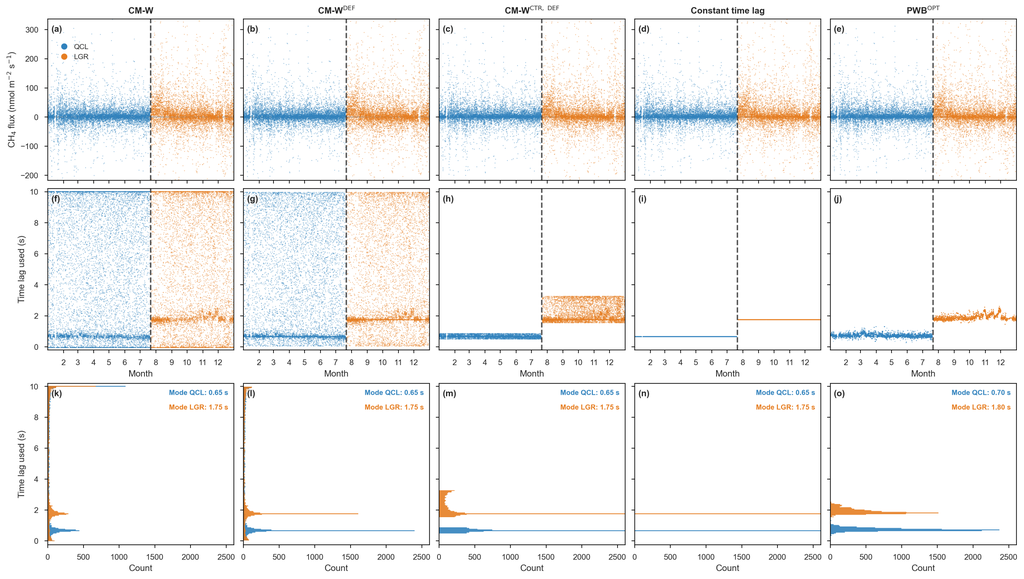

02_merged_ch4.png

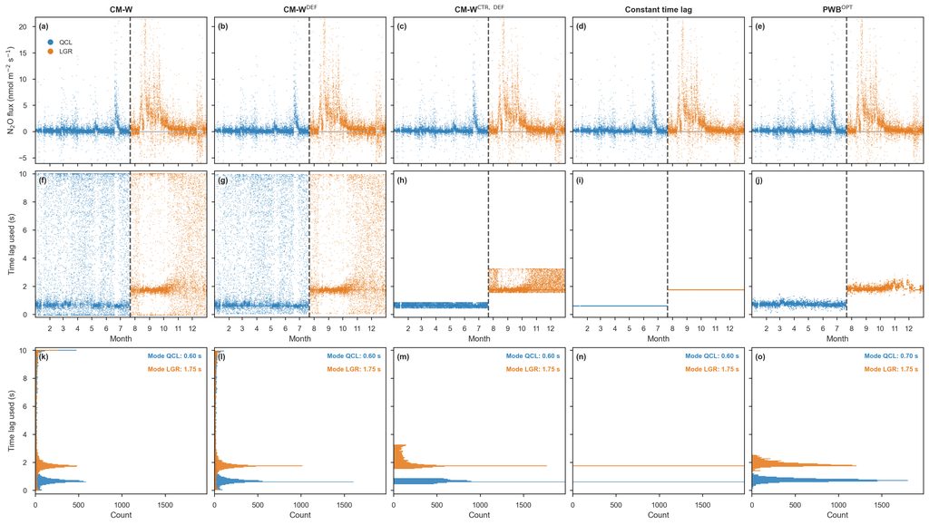

02_merged_n2o.png

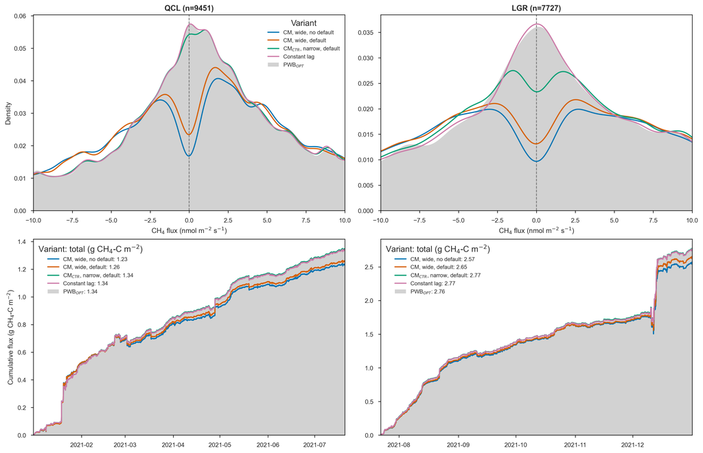

03_cumulative_ch4.png

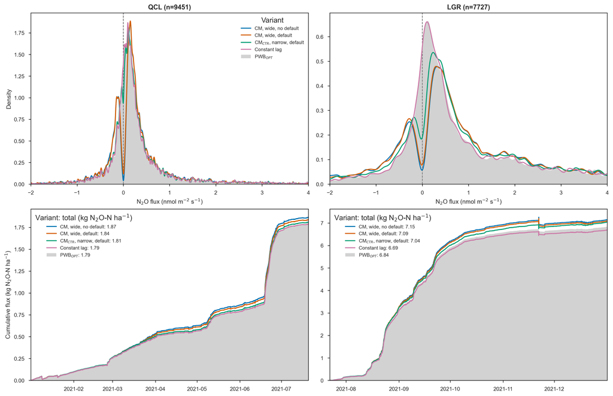

03_cumulative_n2o.png

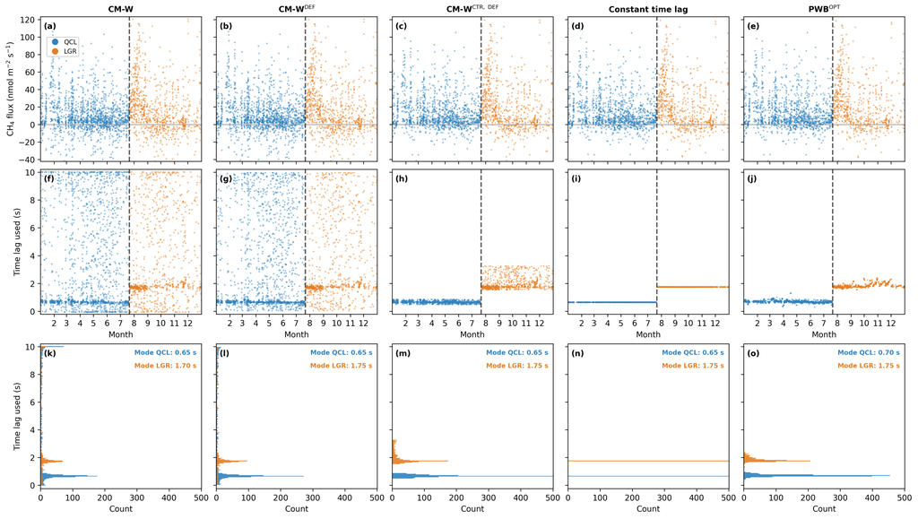

08_cut_50_merged_ch4.png

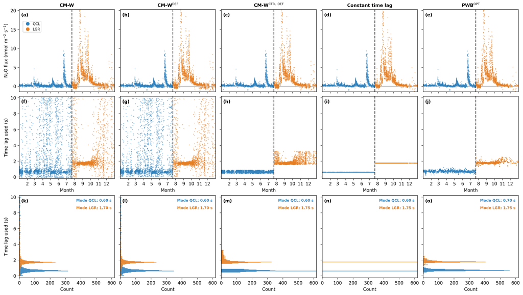

08_cut_50_merged_n2o.png

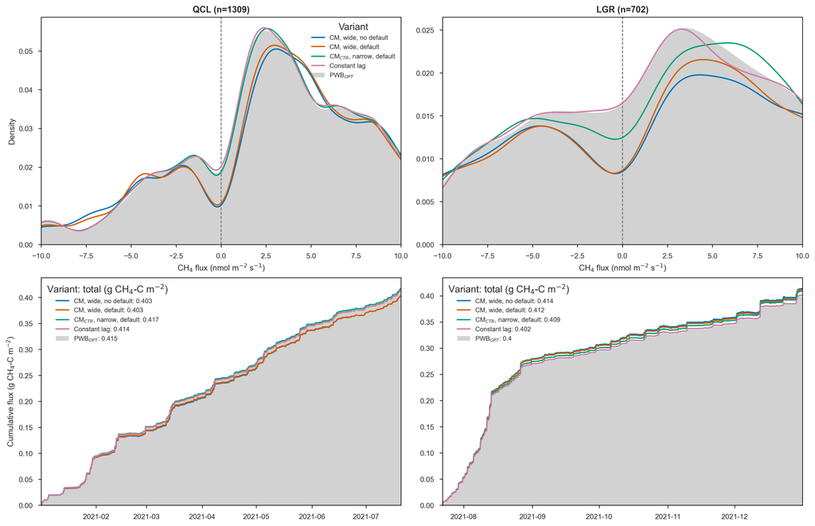

09_cumulative_cut_50_ch4.png

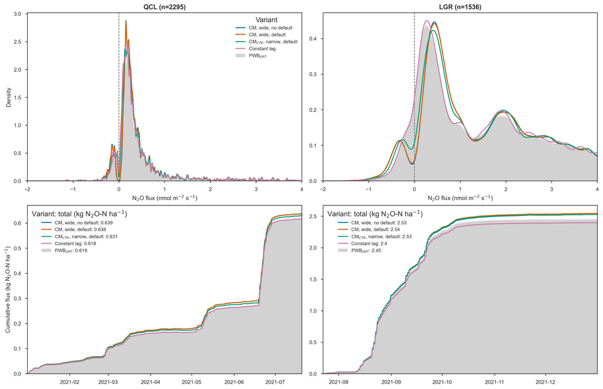

09_cumulative_cut_50_n2o.png

```python
EXTS = ("*.png", "*.jpg", "*.jpeg", "*.gif", "*.svg")
MIME = {".png": "image/png", ".jpg": "image/jpeg", ".jpeg": "image/jpeg",
        ".gif": "image/gif", ".svg": "image/svg+xml"}


def figure_grid(paths):
    # Base64-embedded image grid (self-contained in the built book).
    cards = []
    for p in paths:
        b64 = base64.b64encode(p.read_bytes()).decode()
        mime = MIME.get(p.suffix.lower(), "image/png")
        cards.append(
            '<figure style="margin:0">'
            f'<img src="data:{mime};base64,{b64}" '
            'style="width:100%;height:auto;border:1px solid #ccc;border-radius:4px"/>'
            f'<figcaption style="font-size:0.8em;text-align:center;word-break:break-all">{p.name}</figcaption>'
            '</figure>'
        )
    return HTML(
        '<div style="display:grid;'
        'grid-template-columns:repeat(auto-fill,minmax(320px,1fr));gap:1rem">'
        + "".join(cards) + "</div>"
    )


images = sorted(p for ext in EXTS for p in FIGDIR.glob(ext))
print(f"Found {len(images)} figure(s) (all quality-controlled results).")

display(Markdown("### Figures (quality-controlled fluxes: notebooks 08, 09)"))
display(figure_grid(images) if images
        else Markdown("_None yet. Run notebooks 08 and 09._"))
```

## Runtime

```python
NB_END = datetime.now()
print(f"Start:    {NB_START:%Y-%m-%d %H:%M:%S}")
print(f"End:      {NB_END:%Y-%m-%d %H:%M:%S}")
print(f"Runtime:  {NB_END - NB_START}")
```

```
Start:    2026-07-14 01:47:18
End:      2026-07-14 01:47:20
Runtime:  0:00:02.290808
```

Back to top